# Quiz I

```python
from tools.Image import Image
from tools.GaussianBlur import GaussianBlur
import matplotlib.pyplot as plt
import numpy as np
import cv2
```

## 1.1

10 points. 1 hrs. Using Python, compute and print the matrix for a Gaussian kernel with σ = 3 using kernel size of 19x19 (we use width = ceiling (6*σ), but an odd no.). Print the kernel as output.

**Answer Explaining**  
I write my own `Gaussian Blur` in `gaussian_blur.py` as a class then use it in this file. inspect code in `gaussian_blur.py` for more detail.

Code below is how to show my gaussian blur by initial sigma and the kernel size. and display the kerel with `plt.imshow`

```
56.5486677571401
```

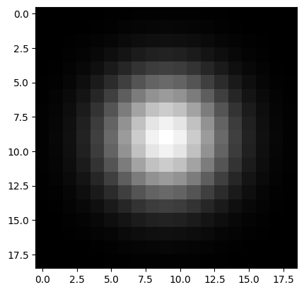

```python
gau = GaussianBlur(19, 3)
plt.imshow(gau.kernel, cmap='gray')
```

Code of `GaussianBlur` class

```
import numpy as np
import cv2


class GaussianBlur:
    def __init__(self, kernel_size: int, sigma: int):
        """
        kernel_size must be odd and square
        """
        self.kernel_size = np.array(kernel_size)
        self.sigma = np.array(sigma)
        self.C = self.__C()
        print(self.C)
        self.kernel = self.__generate_kernel()

    def __generate_kernel(self):
        kernel = np.zeros((self.kernel_size, self.kernel_size))
        center = self.kernel_size // 2
        for i in range(self.kernel_size):
            for j in range(self.kernel_size):
                # Adjust indices to be relative to center
                i_adjusted = i - center
                j_adjusted = j - center
                kernel[i][j] = self.__G_ij(i_adjusted, j_adjusted)

        return kernel

    def __C(self):
        sum_of_sum = np.array(
            [
                self.__g_ij(i, j)
                for i in range(-self.kernel_size, self.kernel_size + 1)
                for j in range(-self.kernel_size, self.kernel_size + 1)
            ]
        )
        return sum_of_sum.sum()

    def __g_ij(self, i: int, j: int):
        return np.exp(-((i**2 + j**2)) / (2 * self.sigma**2))

    def __G_ij(self, i: int, j: int):
        return (self.__g_ij(i, j) / self.__g_ij(0, 0)) / self.C

    def filter(self, image: np.ndarray, kernel: np.ndarray) -> np.ndarray:
        return cv2.filter2D(image, -1, kernel)
```

## 1.2

10 points. 0.5 hrs. Modify the OpenCV code shown in class to show the result of the convolution of your 19 x 19 Gaussian kernel using the Lenna image.

**Explain answer** First, I import the image using my own `Image` class by filen name.

```python
image = Image.from_file("./Q1/Lenna.png")
```

Then show the image before use Gaussian Blur

[figure not shown]

```python
image.display()
```

Use

```
Image.gaussian_blur(kernel_size, sigma)
```

I write gaussian implementation in Image class as method. This method will generate gaussian and then filter it and set filtered image to `self.image`

```python
image.gaussian_blur(19, 3)
```

```
56.5486677571401
```

[figure not shown]

```python
image.display()
```

# 2

Template Matching. Search for the ‘t’ using “t_character.png” as template in the text image “text_image.png”. Use a bounding box to mark where ‘t’ were found for each of these 2 cases:

## 2.1

Use the Euclidean norm to report minimal values as “t”. You may use OpenCV to only read and write the image, but not to call the template matching library function.

Load Template

```python
template = Image.from_file("./Q1/t_character.png", mode='L')
```

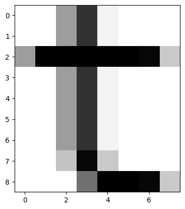

```python
template.display()
```

```python
template.image.shape
```

```
(9, 8)
```

Load Image

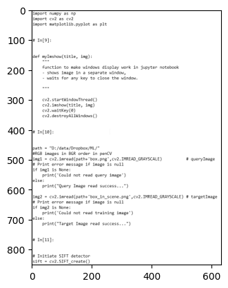

```python
TemMatch  = Image.from_file("./Q1/text_image.png", mode='L')
TemMatch.display()
```

```python
matchMark = TemMatch.templateMatching(template)
```

my `templateMatching` Code

```
def templateMatching(self, pattern: Image) -> List[Marker]:
    '''
    pattern: np.ndarray of shape (n, m)

    this method will recieve a pattern and return a list of markers (top_left, bottom_right) of the pattern in the image.
    '''
    template = TemplateMatch(pattern)
    return template.matching(self)
```

and `TemplateMatching` Class

```
class TemplateMatch:
    def __init__(self, template: Image):
        self.template = template
        self.t_height, self.t_width, *_ = template.image.shape

    @staticmethod
    def from_file(path: str) -> TemplateMatch:
        return TemplateMatch(np.array(PILImage.open(path)))

    def __SSD(self, image: np.ndarray) -> np.float64:
        '''
        SSD: Sum of Squared Difference
        in this case, it also know as 1D Euclidean distance
        '''
        assert (
            image.shape == self.template.image.shape
        ), "image and template must have the same shape"
        return np.sum((image - self.template.image) ** 2)

    def matching(self, image: Image) -> List[Marker]:
        markers: List[Marker] = []
        for i in range(image.image.shape[0] - self.t_height):
            for j in range(image.image.shape[1] - self.t_width):
                foucsed_image = image.image[i:i+self.t_height, j:j+self.t_width]
                if self.__SSD(foucsed_image) == 0:
                    markers.append(((j, i), (j+self.t_width, i+self.t_height)))

        return markers
```

```python
"found " + str(len(matchMark)) + " matches"
```

```
'found 45 matches'
```

[output not shown]

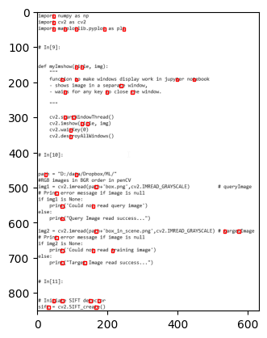

```python
TemMatch.draw_rectangle(matchMark, "r")
```

## 2.2

Use convolution to report high values as “t”. You may fully use OpenCV including convolution.

```python
conv_temp = cv2.matchTemplate(TemMatch.image, template.image, cv2.TM_CCOEFF_NORMED)
threshold = 1
loc = np.where(conv_temp >= threshold)

for pt in zip(*loc[::-1]):
    cv2.rectangle(TemMatch.image, pt, (pt[0] + template.image.shape[1], pt[1] + template.image.shape[0]), (0, 0, 255), 2)
```

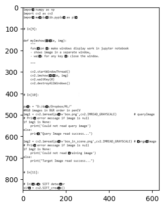

```python
plt.imshow(TemMatch.image, cmap='gray')
```

## 3

KNN (K nearest neighbor) for 3 Classes. Modify the provided program for KNN with 2 random red/blue classes shown in class to have 3 classes of red/blue/yellow instead. Then use K = 4 to classify a randomly generated sample as red, yellow, or blue.

```python
# Feature set containing 25 * 2 for 25 (x,y) values of known/training data that are random integers 0-99
trainData = np.random.randint(0,100,(100,2)).astype(np.float32) #25 of (x,y) float values, each random int 0..99. Matrix 25x2
# Label each one either Red or Blue with numbers 0 and 1. Response is a random integers 0-1 of 25 * 1 values
responses = np.random.randint(0,3,(100,1)).astype(np.float32) #25 values of (x) each random 0..1.  Matrix 25x1.  0 - Red, 1 - Blue.
```

```python
trainData.shape, responses.shape
```

```
((100, 2), (100, 1))
```

```python
responses_flat = responses.ravel() #this is a vector
responses_flat.shape
```

```
(100,)
```

```python
red = trainData[responses.ravel()==0] #red is now trained data with responses of 0
# print(red)
blue = trainData[responses.ravel()==1] #blue is now trained data with responses of 1
# print(blue)
yellow = trainData[responses.ravel()==2] #blue is now trained data with responses of 1
# print(yellow)
```

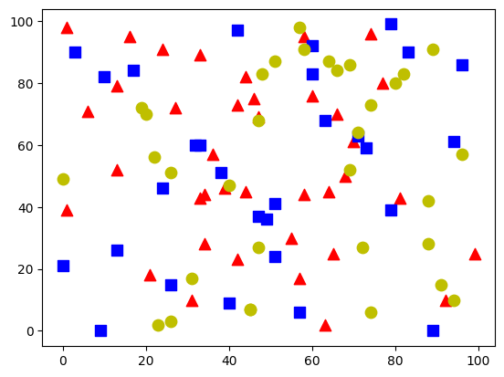

```python
plt.scatter(red[:,0],red[:,1],80,'r','^') #size 80, red, triangle
plt.scatter(blue[:,0],blue[:,1],80,'b','s') #size 80, blue, square
plt.scatter(yellow[:,0],yellow[:,1],80,'y','o') #size 80, blue, square
plt.show()
```

Test new Data

```python
newcomer = np.random.randint(0,100,(1,2)).astype(np.float32)
print(newcomer)
```

```
[[28. 60.]]
```

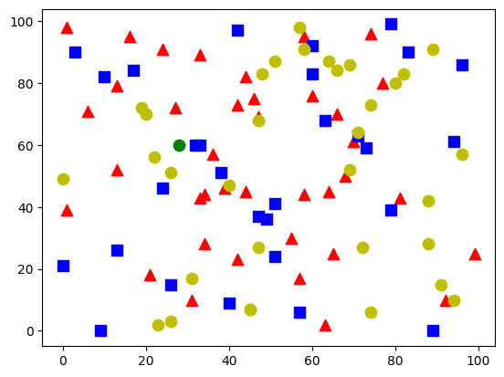

```python
plt.scatter(red[:,0],red[:,1],80,'r','^') #red, triangle
plt.scatter(blue[:,0],blue[:,1],80,'b','s') #blue, square
plt.scatter(yellow[:,0],yellow[:,1],80,'y','o') #blue, square
plt.scatter(newcomer[:,0],newcomer[:,1],80,'g','o') #green, circle
plt.show()
```

Update k to 4

```python
colorName = np.array(['Red', 'Blue', 'Yellow'])
knn = cv2.ml.KNearest_create() #object knn from class.
knn.train(trainData, cv2.ml.ROW_SAMPLE, responses) #training data and the response label is fed into model.
k = 4 #set the no. of nearest neighbors to use
ret, results, neighbors, dist = knn.findNearest(newcomer, k) #KNN is called to classify newcomer.
```

```python
resultColor = colorName[results[0].astype(int)]
neighborColors = colorName[neighbors[0].astype(int)]
```

```python
print( "result color:  {}\n".format(resultColor) )
print( "neighbors:  {}\n".format(neighbors) )
print( "neighbor colors:  {}\n".format(neighborColors) )
print( "neighbor distances:  {}\n".format(dist[0]) )
```

```
result color:  ['Blue']

neighbors:  [[1. 1. 2. 0.]]

neighbor colors:  ['Blue' 'Blue' 'Yellow' 'Red']

neighbor distances:  [16. 25. 52. 73.]
```

# 4

```python
import pandas as pd
```

```python
df = pd.read_csv('./Q1/salmon_seabass.csv')
df.head()
```

|  | index | lightness | width | species |
| --- | --- | --- | --- | --- |
| 0 | 0 | 2.834754 | 21.087143 | 0 |
| 1 | 1 | 3.329180 | 18.877143 | 0 |
| 2 | 2 | 3.690492 | 19.824286 | 0 |
| 3 | 3 | 4.812459 | 17.760000 | 0 |
| 4 | 4 | 4.812459 | 16.497143 | 0 |

```python
salmon = df[df['species'] == 0]
seabass = df[df['species'] == 1]
```

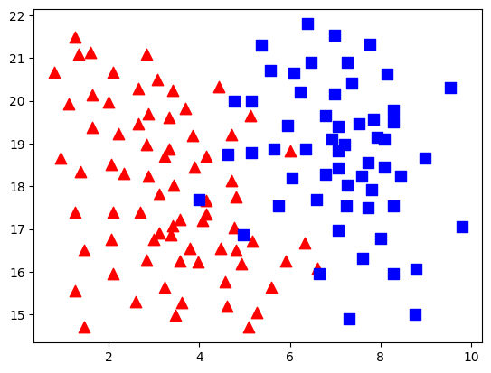

```python
plt.scatter(salmon['lightness'], salmon['width'], 80, 'r', '^')
plt.scatter(seabass['lightness'], seabass['width'], 80, 'b', 's')
```

```python
df
```

|  | index | lightness | width | species |
| --- | --- | --- | --- | --- |
| 0 | 0 | 2.834754 | 21.087143 | 0 |
| 1 | 1 | 3.329180 | 18.877143 | 0 |
| 2 | 2 | 3.690492 | 19.824286 | 0 |
| 3 | 3 | 4.812459 | 17.760000 | 0 |
| 4 | 4 | 4.812459 | 16.497143 | 0 |
| ... | ... | ... | ... | ... |
| 126 | 126 | 8.976774 | 18.656940 | 1 |
| 127 | 127 | 5.365806 | 21.308897 | 1 |
| 128 | 128 | 6.226452 | 20.203915 | 1 |
| 129 | 129 | 8.789677 | 16.054093 | 1 |
| 130 | 130 | 9.800000 | 17.060854 | 1 |

131 rows × 4 columns

```python
def find_nearest_neighbors(k, target, data: pd.DataFrame):
    distance = []
    for i in range(len(data)):
        x = data.iloc[i]['lightness']
        y = data.iloc[i]['width']
        label = data.iloc[i]['species']
        d = np.sqrt((x - target['lightness']) ** 2 + (y - target['width']) ** 2)
        distance.append((d, label))


    distance = np.array(distance)
    # sort by first column, remove distance between target and target
    distance = distance[distance[1:, 0].argsort()]

    cls = distance[:k, 1]
    # return the most frequent class
    return np.argmax(np.bincount(cls.astype(int)))
```

```python
predict = []

for target in range(len(df)):
    predict.append(find_nearest_neighbors(5, df.iloc[target], df))

df['predict'] = predict

df.head()
```

|  | index | lightness | width | species | predict |
| --- | --- | --- | --- | --- | --- |
| 0 | 0 | 2.834754 | 21.087143 | 0 | 0 |
| 1 | 1 | 3.329180 | 18.877143 | 0 | 0 |
| 2 | 2 | 3.690492 | 19.824286 | 0 | 0 |
| 3 | 3 | 4.812459 | 17.760000 | 0 | 0 |
| 4 | 4 | 4.812459 | 16.497143 | 0 | 0 |

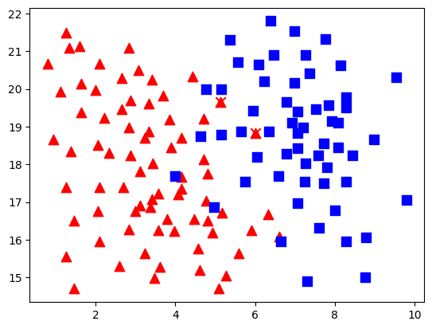

```python
plt.scatter(df[df['species'] == 0]['lightness'], df[df['species'] == 0]['width'], 80, 'r', '^')
plt.scatter(df[df['species'] == 1]['lightness'], df[df['species'] == 1]['width'], 80, 'b', 's')
plt.scatter(df[(df['species'] == 0) & (df['predict'] == 1)]['lightness'], df[(df['species'] == 0) & (df['predict'] == 1)]['width'], 80, 'r', 'x')
plt.scatter(df[(df['species'] == 1) & (df['predict'] == 0)]['lightness'], df[(df['species'] == 1) & (df['predict'] == 0)]['width'], 80, 'b', 'x')
plt.show()
```

# 5

Image Matching with KNN. Create a query image of an object you photographed yourself. Then photograph that same object but in a different environment with some other background objects as a target image. Try the provided image search colab to search for the query image. Show the “good matches” that includes the query and target images with SIFT features and matching lines as done in the colab.

```python
import cv2 as cv2
```

```python
query = Image.from_file("./Q1/IMG_4588.jpg", mode='RGB')
target = Image.from_file("./Q1/IMG_4589.jpg", mode='RGB')
```

[figure not shown]

```python
query.display()
```

[figure not shown]

```python
target.display()
```

```python
sift = cv2.SIFT_create()
```

```python
kp1, des1 = sift.detectAndCompute(query.image,None) #find SIFT features for Query
kp2, des2 = sift.detectAndCompute(target.image,None) #find SIFT features for Target
```

```python
print(kp1[0], '\n',des1[0], '\n Size = ', des1[0].size)
```

```
< cv2.KeyPoint 0x15fe5de30>
 [ 23.  11.   4.   1.   2.   5.  14.   9.  45.  20.  19.  12.   9.   5.
   1.  21. 174.  10.   0.   2.   3.   2.   1.  92. 134.  30.   0.   1.
  12.   3.   0.  25.   1.   1.   3.   8.   7.   5.   5.   3.  71.  47.
  21.  19.  11.   2.   1.  10. 174.  50.   4.   1.   0.   0.   0.  47.
 151.   3.   0.   1.  18.   2.   1.  55.   0.   0.   0.   6.   3.   1.
   1.   0.  88.   6.   3.  26.  10.   1.   1.  45. 174.  33.   1.   1.
   0.   0.   0.  41. 174.  16.   0.   9.  29.   1.   1.  19.   0.   0.
   0.   0.   0.   0.   0.   0.  27.   0.   0.   0.   0.   0.   0.  12.
 174.  15.   0.   0.   0.   0.   0.  30. 147.  21.   1.   8.  30.   2.
   0.   5.]
 Size =  128
```

```python
kp1[0].pt, kp1[0].size, kp1[0].angle #print first keypoint feature: {position (x,y), size, and orientation angle}.
```

```
((2.839599609375, 2575.992919921875), 2.0611789226531982, 42.119049072265625)
```

```python
# BFMatcher with default params
bf = cv2.BFMatcher()
#if you use knnMatch, it will return a list of (the best) k matches instead of a single DMatch.
#in our example k=2, so will get a list of best 2 matches per feature point
matches = bf.knnMatch(des1,des2,k=2) #k = 2
```

```python
good = []
for m,n in matches:
    if m.distance < 0.75*n.distance:
        good.append([m])
```

```python
img3 = cv2.drawMatchesKnn(query.image,kp1,target.image,kp2,good,None,flags=cv2.DrawMatchesFlags_DRAW_RICH_KEYPOINTS)
```

[figure not shown]

```
(<matplotlib.image.AxesImage at 0x15f839e10>, None)
```

```python
plt.imshow(img3),plt.show()
```